# Проект: Поиск клиента с неоптимальными тарифами

## Общая информация

**Вывод**

В данных были обнаружены пропуски. В столбце internal пропущено 117 значений, что составляет 0,22% от общего числа. В столбце operator_id пропущено 8172 значения, или 15%. Также было выявлено 4900 дублированных строк, что составляет 9% от общего количества.

Было установлено, что большинство пользователей совершают от одного до пяти звонков в день. Продолжительность звонков, включая время гудков, варьируется от 46 минут до 901 минуты.

Стоит отметить, что 50% звонков остаются без ответа. В 9 и 10 месяце 7% клиентов, или 21 клиент, не совершили ни одного звонка. В 8 месяце 72% клиентов говорили 0 минут, а в 9 — 43%.

На основе этих данных было решено отобрать пользователей для дальнейшего анализа. В результате в таблицу вошли 109 клиента.

В результате была создана таблица the_end, в которой отражены клиенты, использующие неоптимальный тариф всего их 71. Из таблицы видно, что чаще всего клиентам с тарифом «B» предлагалось перейти на новый тариф.

Также было проведено два статистических теста Манна-Уитни. Один из тестов выявил, что средняя продолжительность общего времени исходящего звонка у клиентов с тарифов A и B не различается. Поэтому потенциально клиенты с тарифом 'A' используют его неоптимально.

В завершение хотелось бы отметить, что клиенты, переходящие на новый тариф, в среднем могут сэкономить до 20%.

Также были построены графики, отражающие разницу в выручке в зависимости от того, остался клиент на старом тарифе или перешел на новый. Эта информация отображена в презентации по этой ссылке https://disk.yandex.ru/i/qLLElvxDb9YPJQ

**Задача:**  
Найти клиентов, которые:  
а) переплачивают на текущих тарифах;  
Итоговый результат: таблица с индикатором клиента — старый тариф — новый тариф.  
b) что будет если мы переведем на более оптимальный тариф(как изменится наша выручка и другие показатели)

**Ежемесячная плата за тариф:** Тариф А — 4000 ₽, Тариф B — 2000 ₽, Тариф С — 1000 ₽.

**Дополнительная ежемесячная плата за каждого оператора:** Тариф А — 50 ₽, Тариф B — 150 ₽, Тариф С — 300 ₽.  
Входящие и внутренние звонки — бесплатны на всех тарифах,

**Исходящие звонки внутри сети, включённые в тариф:** Тариф А — 2000 минут, Тариф B — 500 минут, Тариф С — нет.

**Цена сверх лимита:** A — 0.1 ₽/мин., B — 0.15 ₽/мин., C — 0.3 ₽/мин.

**Исходящие звонки, кроме внутренних:** A — 0.3 ₽/мин., B — 0.5 ₽/мин., C — 0.7 ₽/мин.

1. Предобработка данных
- пропуски
- тип данных
- дубликаты
2. Проведите исследовательский анализ данных
- проанализировать выбросы и аномалии
- принять решение об активных пользователях
- посмотреть на период сбора данных и принять решение об использованном периоде
- посмотреть на данные в целом поискать инсайты
3. Найдите клиентов с неоптимальными тарифами
- Получить расходы клиентов на каждом из тарифов
4. Показать изменения в выручке для заказчика (общей, средняя в месяц, средняя на одного клиента в общем выржании и в процентах) при смене тарифов
- проанализировать полученные результаты
5. Проверьте статистические гипотезы

a) Различаются ли средние чеки клиентов на тарифах A и B?  
H0 = среднии чеки клиентов на тарифах A и B не различаются; H1 = средние чеки клиентов на тарифах A и B различаются.

b) Различается ли средняя продолжительность общего времени исходящего звонка в месяц у клиентов в зависимости от тарифов A и B?  
H0 = средняя продолжительность общего времени исходящего звонка у клиентов тарифов A и B не различаются;  
H1 = средняя продолжительность общего времени исходящего звонка у клиентов тарифов A и B различаются.

#### Описание данных

Датасеты описывают использование услуг «Нупозвони» — провайдера виртуальной телефонии. Его клиенты — колл-центры, которые:

- распределяют входящие вызовы на операторов,
- совершают исходящие вызовы силами операторов.

Также операторы могут делать внутренние вызовы — вызовы друг между другом внутри сети виртуальной телефонии.

Датасет /datasets/telecom_dataset.csv Колонки:

- user_id — идентификатор клиента;
- date — дата статистики;
- direction — направление вызовов: out — исходящий вызов, in — входящий;
- internal — маркер внутренних и внешних вызовов;
- operator_id — идентификатор оператора;
- is_missed_call — маркер пропущенных вызовов;
- calls_count — количество звонков;
- call_duration — длительность звонка без учёта времени ожидания;
- total_call_duration — длительность звонка с учётом времени ожидания.

Датасет /datasets/telecom_clients.csv Колонки:

- user_id — идентификатор клиента;
- tariff_plan — тарифный план клиента;
- date_start — дата регистрации клиента в сервисе.

## Предобработка данных

```python
import pandas as pd
import seaborn as sns
import matplotlib.pyplot as plt
import scipy.stats as stats
import numpy as np
```

```python
try:
    df_1 = pd.read_csv('telecom_dataset.csv')
except:
    df_1 = pd.read_csv('/datasets/telecom_dataset.csv')
```

```python
try:
    client = pd.read_csv('telecom_clients.csv')
except:
    client = pd.read_csv(' /datasets/telecom_clients.csv')
```

**Выводим общую информацию двух датафреймов**

```python
df_1.head()
```

|  | user_id | date | direction | internal | operator_id | is_missed_call | calls_count | call_duration | total_call_duration |
| --- | --- | --- | --- | --- | --- | --- | --- | --- | --- |
| 0 | 166377 | 2019-08-04 00:00:00+03:00 | in | False | NaN | True | 2 | 0 | 4 |
| 1 | 166377 | 2019-08-05 00:00:00+03:00 | out | True | 880022.0 | True | 3 | 0 | 5 |
| 2 | 166377 | 2019-08-05 00:00:00+03:00 | out | True | 880020.0 | True | 1 | 0 | 1 |
| 3 | 166377 | 2019-08-05 00:00:00+03:00 | out | True | 880020.0 | False | 1 | 10 | 18 |
| 4 | 166377 | 2019-08-05 00:00:00+03:00 | out | False | 880022.0 | True | 3 | 0 | 25 |

```python
df_1.info()
```

```
<class 'pandas.core.frame.DataFrame'>
RangeIndex: 53902 entries, 0 to 53901
Data columns (total 9 columns):
 #   Column               Non-Null Count  Dtype
---  ------               --------------  -----
 0   user_id              53902 non-null  int64
 1   date                 53902 non-null  object
 2   direction            53902 non-null  object
 3   internal             53785 non-null  object
 4   operator_id          45730 non-null  float64
 5   is_missed_call       53902 non-null  bool
 6   calls_count          53902 non-null  int64
 7   call_duration        53902 non-null  int64
 8   total_call_duration  53902 non-null  int64
dtypes: bool(1), float64(1), int64(4), object(3)
memory usage: 3.3+ MB
```

```python
client.head()
```

|  | user_id | tariff_plan | date_start |
| --- | --- | --- | --- |
| 0 | 166713 | A | 2019-08-15 |
| 1 | 166901 | A | 2019-08-23 |
| 2 | 168527 | A | 2019-10-29 |
| 3 | 167097 | A | 2019-09-01 |
| 4 | 168193 | A | 2019-10-16 |

```python
client.info()
```

```
<class 'pandas.core.frame.DataFrame'>
RangeIndex: 732 entries, 0 to 731
Data columns (total 3 columns):
 #   Column       Non-Null Count  Dtype
---  ------       --------------  -----
 0   user_id      732 non-null    int64
 1   tariff_plan  732 non-null    object
 2   date_start   732 non-null    object
dtypes: int64(1), object(2)
memory usage: 17.3+ KB
```

В таблице df_1 в столбцах internal и operator_id есть пропуски. Также столбец date имеет неверный тип данных

В таблице client нет пропусков, но в столбце date_start неправильный тип данных

**Меняем тип данных**

```python
df_1['date'] = pd.to_datetime(df_1['date'])
df_1['date'] = df_1['date'].dt.tz_localize(None)
client['date_start'] = pd.to_datetime(client['date_start'])

display(df_1['internal'].dtypes)
display(df_1['date'].dtypes)
client['date_start'].dtypes
```

```
dtype('O')
```

```
dtype('<M8[ns]')
```

```
dtype('<M8[ns]')
```

Создаем столбец с месяцами

```python
df_1['month'] = df_1['date'].dt.to_period('M')
```

**Объединяем таблицы**

```python
df_2 = pd.merge(df_1, client, on='user_id', how='inner')
```

```python
df_2.head(10)
```

|  | user_id | date | direction | internal | operator_id | is_missed_call | calls_count | call_duration | total_call_duration | month | tariff_plan | date_start |
| --- | --- | --- | --- | --- | --- | --- | --- | --- | --- | --- | --- | --- |
| 0 | 166377 | 2019-08-04 | in | False | NaN | True | 2 | 0 | 4 | 2019-08 | B | 2019-08-01 |
| 1 | 166377 | 2019-08-05 | out | True | 880022.0 | True | 3 | 0 | 5 | 2019-08 | B | 2019-08-01 |
| 2 | 166377 | 2019-08-05 | out | True | 880020.0 | True | 1 | 0 | 1 | 2019-08 | B | 2019-08-01 |
| 3 | 166377 | 2019-08-05 | out | True | 880020.0 | False | 1 | 10 | 18 | 2019-08 | B | 2019-08-01 |
| 4 | 166377 | 2019-08-05 | out | False | 880022.0 | True | 3 | 0 | 25 | 2019-08 | B | 2019-08-01 |
| 5 | 166377 | 2019-08-05 | out | False | 880020.0 | False | 2 | 3 | 29 | 2019-08 | B | 2019-08-01 |
| 6 | 166377 | 2019-08-05 | out | False | 880020.0 | True | 8 | 0 | 50 | 2019-08 | B | 2019-08-01 |
| 7 | 166377 | 2019-08-05 | in | False | NaN | True | 6 | 0 | 35 | 2019-08 | B | 2019-08-01 |
| 8 | 166377 | 2019-08-05 | out | False | 880020.0 | True | 8 | 0 | 50 | 2019-08 | B | 2019-08-01 |
| 9 | 166377 | 2019-08-06 | in | False | NaN | True | 4 | 0 | 62 | 2019-08 | B | 2019-08-01 |

```python
df_2.info()
```

```
<class 'pandas.core.frame.DataFrame'>
Int64Index: 53902 entries, 0 to 53901
Data columns (total 12 columns):
 #   Column               Non-Null Count  Dtype
---  ------               --------------  -----
 0   user_id              53902 non-null  int64
 1   date                 53902 non-null  datetime64[ns]
 2   direction            53902 non-null  object
 3   internal             53785 non-null  object
 4   operator_id          45730 non-null  float64
 5   is_missed_call       53902 non-null  bool
 6   calls_count          53902 non-null  int64
 7   call_duration        53902 non-null  int64
 8   total_call_duration  53902 non-null  int64
 9   month                53902 non-null  period[M]
 10  tariff_plan          53902 non-null  object
 11  date_start           53902 non-null  datetime64[ns]
dtypes: bool(1), datetime64[ns](2), float64(1), int64(4), object(3), period[M](1)
memory usage: 5.0+ MB
```

```python
df_1['user_id'].nunique()
```

```
307
```

В таблицу вошли не все клиенты, в основую таблицу вошли 307 клиентов

**Смотрим пропуски в данных**

```python
display(df_2.isnull().sum())
df_2.isnull().mean() * 100
```

```
user_id                   0
date                      0
direction                 0
internal                117
operator_id            8172
is_missed_call            0
calls_count               0
call_duration             0
total_call_duration       0
month                     0
tariff_plan               0
date_start                0
dtype: int64
```

```
user_id                 0.000000
date                    0.000000
direction               0.000000
internal                0.217061
operator_id            15.160847
is_missed_call          0.000000
calls_count             0.000000
call_duration           0.000000
total_call_duration     0.000000
month                   0.000000
tariff_plan             0.000000
date_start              0.000000
dtype: float64
```

Пропуски не трогаем, так как нельзя найти логику замены пропусков, номер оператора не подбирается, как и марка внутренних и внешних звонков не определяется.

**Смотрим дубликаты**

```python
display(df_2.duplicated().sum())
round(df_2.duplicated().sum() /  df_2['user_id'].count() * 100, 2)
```

```
4900
```

```
9.09
```

Удаляем дубликаты так как каждая целая строка уникальна

```python
df_2 = df_2.drop_duplicates()
df_2.duplicated().sum()
```

```
0
```

```python
df_2['direction'].unique()
```

```
array(['in', 'out'], dtype=object)
```

```python
df_2['tariff_plan'].unique()
```

```
array(['B', 'C', 'A'], dtype=object)
```

Проверили на неявные дубликаты, их нет

**Создаем датафрейм**

```python
creat = pd.DataFrame(  {'month_pay': [4000 ,  2000, 1000],
    'tariff_plan': ['A', 'B', 'C'],
    'add_pay': [50, 150, 300],
    'out_call_min': [2000, 500, 0],
    'over_limit_cost': [0.1, 0.15, 0.3],
    'out_call_cost': [0.3, 0.5, 0.7]})
creat
```

|  | month_pay | tariff_plan | add_pay | out_call_min | over_limit_cost | out_call_cost |
| --- | --- | --- | --- | --- | --- | --- |
| 0 | 4000 | A | 50 | 2000 | 0.10 | 0.3 |
| 1 | 2000 | B | 150 | 500 | 0.15 | 0.5 |
| 2 | 1000 | C | 300 | 0 | 0.30 | 0.7 |

Соединяем таблицы

```python
df = pd.merge(df_2, creat, on='tariff_plan', how='left')
```

```python
df.head()
```

|  | user_id | date | direction | internal | operator_id | is_missed_call | calls_count | call_duration | total_call_duration | month | tariff_plan | date_start | month_pay | add_pay | out_call_min | over_limit_cost | out_call_cost |
| --- | --- | --- | --- | --- | --- | --- | --- | --- | --- | --- | --- | --- | --- | --- | --- | --- | --- |
| 0 | 166377 | 2019-08-04 | in | False | NaN | True | 2 | 0 | 4 | 2019-08 | B | 2019-08-01 | 2000 | 150 | 500 | 0.15 | 0.5 |
| 1 | 166377 | 2019-08-05 | out | True | 880022.0 | True | 3 | 0 | 5 | 2019-08 | B | 2019-08-01 | 2000 | 150 | 500 | 0.15 | 0.5 |
| 2 | 166377 | 2019-08-05 | out | True | 880020.0 | True | 1 | 0 | 1 | 2019-08 | B | 2019-08-01 | 2000 | 150 | 500 | 0.15 | 0.5 |
| 3 | 166377 | 2019-08-05 | out | True | 880020.0 | False | 1 | 10 | 18 | 2019-08 | B | 2019-08-01 | 2000 | 150 | 500 | 0.15 | 0.5 |
| 4 | 166377 | 2019-08-05 | out | False | 880022.0 | True | 3 | 0 | 25 | 2019-08 | B | 2019-08-01 | 2000 | 150 | 500 | 0.15 | 0.5 |

**Промежуточные выводы:** в данных были обнаружены пропуски, а именно в столбцах internal(117 пропусков или 0.22%) и operator_id(8172 пропусков или 15%). Также было обнаружено 4900 строк продублированных данных или 9%.

## Исследовательский анализ данных

**Смотрим на выбросы и аномалии**

Строим гистограмму длительности звонков.

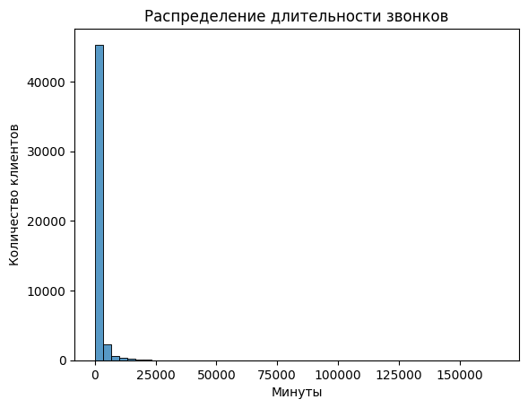

```
count     49002.000000
mean       1156.558202
std        4451.473661
min           0.000000
25%          46.000000
50%         208.000000
75%         901.000000
max      166155.000000
Name: total_call_duration, dtype: float64
```

```python
sns.histplot(x='total_call_duration', data=df, bins=50)
# Настраиваем подписи осей и легенду
plt.xlabel('Минуты')
plt.ylabel('Количество клиентов')
plt.title('Распределение длительности звонков')
plt.show()
df['total_call_duration'].describe()
```

Видно, что основные значения находятся в диапазоне 46 минут и 901 минуты, и есть жирный хвост, который достигает отметки в 166155 минут. Данные фильтруем по принципу рабочего дня. Предполагаем, что оператор работает 10 часов в день, следовательно, он не может выйти за рамки 600 минут в день.

```python
filter = df.query('total_call_duration < 600')
```

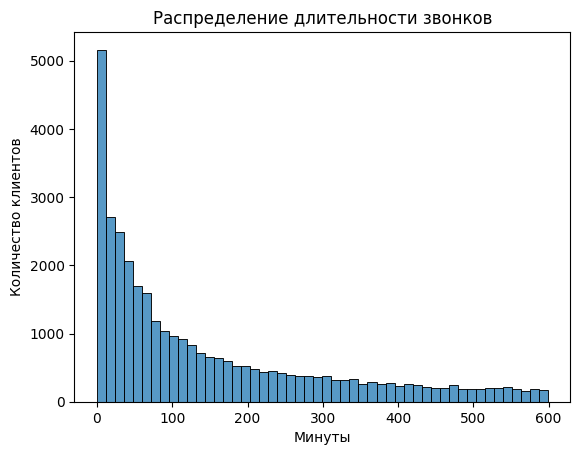

```python
sns.histplot(x='total_call_duration', data=filter, bins=50)
# Настраиваем подписи осей и легенду
plt.xlabel('Минуты')
plt.ylabel('Количество клиентов')
plt.title('Распределение длительности звонков')
plt.show()
```

Строим гистограмму количества звонков.

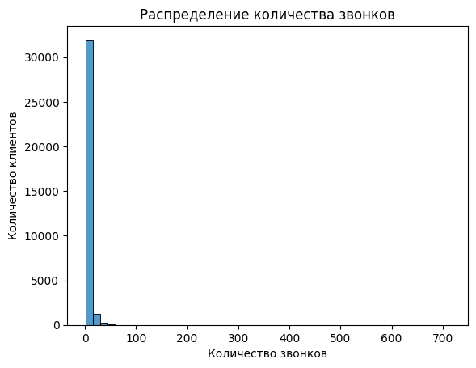

```
count    33493.000000
mean         4.288777
std          8.989728
min          1.000000
25%          1.000000
50%          2.000000
75%          5.000000
max        714.000000
Name: calls_count, dtype: float64
```

```python
sns.histplot(x='calls_count', data=filter, bins=50)
# Настраиваем подписи осей и легенду
plt.xlabel('Количество звонков')
plt.ylabel('Количество клиентов')
plt.title('Распределение количества звонков')
plt.show()
filter['calls_count'].describe()
```

Видим, как основные значения распределены в диапазоне одного звонка и 5 звонков, и есть жирный хвост с отметкой 714. Отфильтруем данные и оставим небольше 20 звонков

Строим гистрограмму количества звонков.

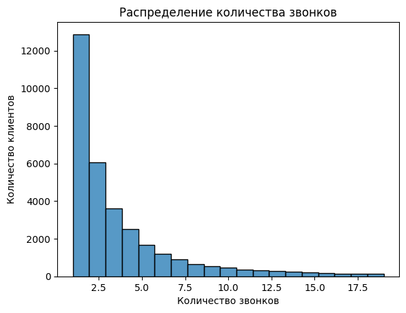

```
count    32479.000000
mean         3.405185
std          3.522135
min          1.000000
25%          1.000000
50%          2.000000
75%          4.000000
max         19.000000
Name: calls_count, dtype: float64
```

```python
filter = filter.query('calls_count < 20')
sns.histplot(x='calls_count', data=filter, bins=19)
# Настраиваем подписи осей и легенду
plt.xlabel('Количество звонков')
plt.ylabel('Количество клиентов')
plt.title('Распределение количества звонков')
plt.show()
filter['calls_count'].describe()
```

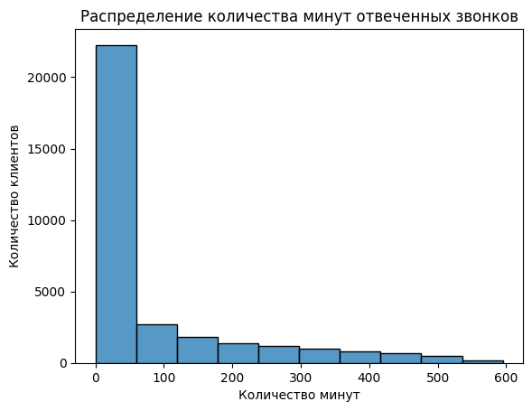

```
count    32479.000000
mean        76.970104
std        130.203588
min          0.000000
25%          0.000000
50%          0.000000
75%        103.000000
max        595.000000
Name: call_duration, dtype: float64
```

```python
sns.histplot(x='call_duration', data=filter, bins=10)
# Настраиваем подписи осей и легенду
plt.xlabel('Количество минут')
plt.ylabel('Количество клиентов')
plt.title('Распределение количества минут отвеченных звонков')
plt.show()
filter['call_duration'].describe()
```

Видно, что 50 процентов звонков остаются неотвеченными. Так же есть жирный хвост с отметкой в 9 часов. Обработаем данные и оставим звонки которые длились небольше 120 минут

Строим гистограмму количества минут состоявшихся разговоров.

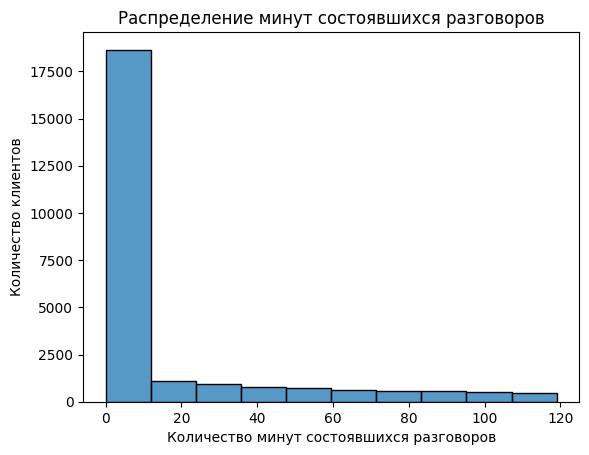

```
count    25001.000000
mean        14.661414
std         29.088082
min          0.000000
25%          0.000000
50%          0.000000
75%         13.000000
max        119.000000
Name: call_duration, dtype: float64
```

```python
filter = filter.query('call_duration < 120')
sns.histplot(x='call_duration', data=filter, bins=10)
# Настраиваем подписи осей и легенду
plt.xlabel('Количество минут состоявшихся разговоров')
plt.ylabel('Количество клиентов')
plt.title('Распределение минут состоявшихся разговоров')
plt.show()
filter['call_duration'].describe()
```

Смотрим на распределение звонков входящих и исходящих.

```python
display(filter['direction'].value_counts())
filter['direction'].value_counts(normalize=True)
```

```
out    14083
in     10918
Name: direction, dtype: int64
```

```
out    0.563297
in     0.436703
Name: direction, dtype: float64
```

Смотрим на то, какие клиенты с какими тарифами преобладают.

```python
display(filter['month_pay'].value_counts())
filter['month_pay'].value_counts(normalize=True)
```

```
1000    10068
2000     9207
4000     5726
Name: month_pay, dtype: int64
```

```
1000    0.402704
2000    0.368265
4000    0.229031
Name: month_pay, dtype: float64
```

**Смотрим на диапазон дат**

```python
display(filter['date_start'].min())
filter['date_start'].max()
```

```
Timestamp('2019-08-01 00:00:00')
```

```
Timestamp('2019-10-31 00:00:00')
```

**Определяем актуальный диапазон**

```python
t = filter.pivot_table(values='total_call_duration', index='user_id', columns='month', aggfunc='sum').reset_index()
t
```

| month | user_id | 2019-08 | 2019-09 | 2019-10 | 2019-11 |
| --- | --- | --- | --- | --- | --- |
| 0 | 166377 | 5042.0 | 11233.0 | 9712.0 | 11013.0 |
| 1 | 166391 | 620.0 | 36.0 | 2.0 | 85.0 |
| 2 | 166392 | 277.0 | 467.0 | 769.0 | 353.0 |
| 3 | 166399 | 244.0 | 230.0 | 315.0 | NaN |
| 4 | 166405 | 4171.0 | 6744.0 | 10741.0 | 16555.0 |
| ... | ... | ... | ... | ... | ... |
| 302 | 168583 | NaN | NaN | 36.0 | 1127.0 |
| 303 | 168598 | NaN | NaN | NaN | 837.0 |
| 304 | 168601 | NaN | NaN | NaN | 2441.0 |
| 305 | 168603 | NaN | NaN | NaN | 316.0 |
| 306 | 168606 | NaN | NaN | NaN | 295.0 |

307 rows × 5 columns

```python
t.isnull().mean() * 100
```

```
month
user_id     0.000000
2019-08    72.312704
2019-09    43.973941
2019-10    11.400651
2019-11    14.983713
dtype: float64
```

В 8 месяце 72 процентов клиентов говорили 0 минут, а в 9 — 43 процента. Об этом стоит сказать заказчику.

Убираем 8 месяц из данных

```python
filter_1 = filter.query('month > "2019-08"')
filter_1['month'].unique()
```

```
<PeriodArray>
['2019-09', '2019-10', '2019-11']
Length: 3, dtype: period[M]
```

**Отбираем активных клиентов**

Мы формируем сводную таблицу, где индексом у нас будет номер клиента, а столбцы будут месяца, и в значениях столбцов выводим суммарное количество минут (total_call_duration), сделанное клиентом за месяц. После чего начинаем фильтровать таблицу по столбцам, где у клиента было nan-значение в 9 и 10 месяце, это означает, что целых два месяца клиент не совершал никаких звонков. Потом проверяем клиентов, которые не совершали звонков в течение трех месяцев. После такой обработки выводим описание таблицы и смотрим на распределение значений. На основании этих значений делаем финальный отбор.

Мы формируем сводную таблицу, где индексом у нас будет номер клиента, а столбцы будут месяца, и в значениях столбцов выводим суммарное количество минут (total_call_duration), сделанное клиентом за месяц.

```python
t1 = filter_1.pivot_table(values='total_call_duration', index='user_id', columns='month', aggfunc='sum').reset_index()
t1.columns = ['user_id', 'm9', 'm10', 'm11']
t1
```

|  | user_id | m9 | m10 | m11 |
| --- | --- | --- | --- | --- |
| 0 | 166377 | 11233.0 | 9712.0 | 11013.0 |
| 1 | 166391 | 36.0 | 2.0 | 85.0 |
| 2 | 166392 | 467.0 | 769.0 | 353.0 |
| 3 | 166399 | 230.0 | 315.0 | NaN |
| 4 | 166405 | 6744.0 | 10741.0 | 16555.0 |
| ... | ... | ... | ... | ... |
| 298 | 168583 | NaN | 36.0 | 1127.0 |
| 299 | 168598 | NaN | NaN | 837.0 |
| 300 | 168601 | NaN | NaN | 2441.0 |
| 301 | 168603 | NaN | NaN | 316.0 |
| 302 | 168606 | NaN | NaN | 295.0 |

303 rows × 4 columns

Смотрим сколько клиентов не совершило ни одного звонка за два месяца

```python
nan_user = t1[t1[['m9', 'm10']].isnull().all(axis=1)]['user_id']
```

```python
display(nan_user.count())
nan_user.count() / t1['user_id'].count() * 100
```

```
21
```

```
6.9306930693069315
```

После чего начинаем фильтровать таблицу по столбцам, где у клиента было nan-значение в 9 и 10 месяце, это означает, что целых два месяца клиент не совершал никаких звонков. Потом проверяем клиентов, которые не совершали звонков в течение трех месяцев.

```python
t2 = t1.dropna(subset=['m9', 'm10'])
t3 = t2.dropna(subset=['m9', 'm10', 'm11'])
t3.isnull().sum()
```

```
user_id    0
m9         0
m10        0
m11        0
dtype: int64
```

После такой обработки выводим описание таблицы и смотрим на распределение значений. На основании этих значений делаем финальный отбор.

```python
t3.describe()
```

|  | user_id | m9 | m10 | m11 |
| --- | --- | --- | --- | --- |
| count | 138.000000 | 138.000000 | 138.000000 | 138.000000 |
| mean | 167030.811594 | 2052.173913 | 3709.485507 | 3618.210145 |
| std | 377.870069 | 3503.015470 | 4792.223215 | 5092.265593 |
| min | 166377.000000 | 2.000000 | 2.000000 | 2.000000 |
| 25% | 166708.750000 | 218.250000 | 571.750000 | 378.500000 |
| 50% | 167017.500000 | 779.500000 | 1830.500000 | 1651.500000 |
| 75% | 167283.750000 | 2463.000000 | 4637.000000 | 5025.250000 |
| max | 167781.000000 | 25823.000000 | 26784.000000 | 30850.000000 |

Убираем тех у кого меньше 60 мин в месяц

```python
min = 60
```

```python
t3 = t3.query('m9 > @min and m10 > @min and m11 > @min')
t3.describe()
```

|  | user_id | m9 | m10 | m11 |
| --- | --- | --- | --- | --- |
| count | 110.000000 | 110.000000 | 110.000000 | 110.000000 |
| mean | 167012.200000 | 2516.109091 | 4490.436364 | 4345.254545 |
| std | 352.470932 | 3780.793724 | 5054.374892 | 5415.701589 |
| min | 166377.000000 | 85.000000 | 86.000000 | 79.000000 |
| 25% | 166714.000000 | 421.750000 | 1082.750000 | 751.250000 |
| 50% | 167002.500000 | 1255.000000 | 2689.500000 | 2438.500000 |
| 75% | 167263.750000 | 3026.750000 | 6311.250000 | 5684.500000 |
| max | 167716.000000 | 25823.000000 | 26784.000000 | 30850.000000 |

```python
t3 = t3.query('user_id != 166975')
```

```python
t3['user_id'].count()
```

```
109
```

Таким образом, мы отобрали 109 активных клиента, осталось дабавить их в основную таблицу.

```python
data = pd.merge(t3, filter_1, on='user_id', how='left')
```

```python
data
```

|  | user_id | m9 | m10 | m11 | date | direction | internal | operator_id | is_missed_call | calls_count | call_duration | total_call_duration | month | tariff_plan | date_start | month_pay | add_pay | out_call_min | over_limit_cost | out_call_cost |
| --- | --- | --- | --- | --- | --- | --- | --- | --- | --- | --- | --- | --- | --- | --- | --- | --- | --- | --- | --- | --- |
| 0 | 166377 | 11233.0 | 9712.0 | 11013.0 | 2019-09-02 | in | False | 880028.0 | False | 2 | 66 | 75 | 2019-09 | B | 2019-08-01 | 2000 | 150 | 500 | 0.15 | 0.5 |
| 1 | 166377 | 11233.0 | 9712.0 | 11013.0 | 2019-09-02 | in | False | 880026.0 | False | 1 | 31 | 34 | 2019-09 | B | 2019-08-01 | 2000 | 150 | 500 | 0.15 | 0.5 |
| 2 | 166377 | 11233.0 | 9712.0 | 11013.0 | 2019-09-02 | out | False | 880026.0 | True | 6 | 0 | 168 | 2019-09 | B | 2019-08-01 | 2000 | 150 | 500 | 0.15 | 0.5 |
| 3 | 166377 | 11233.0 | 9712.0 | 11013.0 | 2019-09-02 | out | True | 880020.0 | True | 2 | 0 | 0 | 2019-09 | B | 2019-08-01 | 2000 | 150 | 500 | 0.15 | 0.5 |
| 4 | 166377 | 11233.0 | 9712.0 | 11013.0 | 2019-09-02 | out | False | 880020.0 | True | 2 | 0 | 3 | 2019-09 | B | 2019-08-01 | 2000 | 150 | 500 | 0.15 | 0.5 |
| ... | ... | ... | ... | ... | ... | ... | ... | ... | ... | ... | ... | ... | ... | ... | ... | ... | ... | ... | ... | ... |
| 15385 | 167716 | 599.0 | 4601.0 | 4787.0 | 2019-11-25 | out | False | 922142.0 | True | 9 | 0 | 330 | 2019-11 | B | 2019-09-26 | 2000 | 150 | 500 | 0.15 | 0.5 |
| 15386 | 167716 | 599.0 | 4601.0 | 4787.0 | 2019-11-25 | in | False | NaN | True | 1 | 0 | 5 | 2019-11 | B | 2019-09-26 | 2000 | 150 | 500 | 0.15 | 0.5 |
| 15387 | 167716 | 599.0 | 4601.0 | 4787.0 | 2019-11-26 | out | False | 922142.0 | True | 8 | 0 | 193 | 2019-11 | B | 2019-09-26 | 2000 | 150 | 500 | 0.15 | 0.5 |
| 15388 | 167716 | 599.0 | 4601.0 | 4787.0 | 2019-11-27 | out | False | 922142.0 | True | 5 | 0 | 158 | 2019-11 | B | 2019-09-26 | 2000 | 150 | 500 | 0.15 | 0.5 |
| 15389 | 167716 | 599.0 | 4601.0 | 4787.0 | 2019-11-28 | out | False | 922142.0 | True | 1 | 0 | 35 | 2019-11 | B | 2019-09-26 | 2000 | 150 | 500 | 0.15 | 0.5 |

15390 rows × 20 columns

Удаляем ненужные столбцы.

```python
data = data.drop(['m9', 'm10', 'm11'], axis=1)
```

```python
data
```

|  | user_id | date | direction | internal | operator_id | is_missed_call | calls_count | call_duration | total_call_duration | month | tariff_plan | date_start | month_pay | add_pay | out_call_min | over_limit_cost | out_call_cost |
| --- | --- | --- | --- | --- | --- | --- | --- | --- | --- | --- | --- | --- | --- | --- | --- | --- | --- |
| 0 | 166377 | 2019-09-02 | in | False | 880028.0 | False | 2 | 66 | 75 | 2019-09 | B | 2019-08-01 | 2000 | 150 | 500 | 0.15 | 0.5 |
| 1 | 166377 | 2019-09-02 | in | False | 880026.0 | False | 1 | 31 | 34 | 2019-09 | B | 2019-08-01 | 2000 | 150 | 500 | 0.15 | 0.5 |
| 2 | 166377 | 2019-09-02 | out | False | 880026.0 | True | 6 | 0 | 168 | 2019-09 | B | 2019-08-01 | 2000 | 150 | 500 | 0.15 | 0.5 |
| 3 | 166377 | 2019-09-02 | out | True | 880020.0 | True | 2 | 0 | 0 | 2019-09 | B | 2019-08-01 | 2000 | 150 | 500 | 0.15 | 0.5 |
| 4 | 166377 | 2019-09-02 | out | False | 880020.0 | True | 2 | 0 | 3 | 2019-09 | B | 2019-08-01 | 2000 | 150 | 500 | 0.15 | 0.5 |
| ... | ... | ... | ... | ... | ... | ... | ... | ... | ... | ... | ... | ... | ... | ... | ... | ... | ... |
| 15385 | 167716 | 2019-11-25 | out | False | 922142.0 | True | 9 | 0 | 330 | 2019-11 | B | 2019-09-26 | 2000 | 150 | 500 | 0.15 | 0.5 |
| 15386 | 167716 | 2019-11-25 | in | False | NaN | True | 1 | 0 | 5 | 2019-11 | B | 2019-09-26 | 2000 | 150 | 500 | 0.15 | 0.5 |
| 15387 | 167716 | 2019-11-26 | out | False | 922142.0 | True | 8 | 0 | 193 | 2019-11 | B | 2019-09-26 | 2000 | 150 | 500 | 0.15 | 0.5 |
| 15388 | 167716 | 2019-11-27 | out | False | 922142.0 | True | 5 | 0 | 158 | 2019-11 | B | 2019-09-26 | 2000 | 150 | 500 | 0.15 | 0.5 |
| 15389 | 167716 | 2019-11-28 | out | False | 922142.0 | True | 1 | 0 | 35 | 2019-11 | B | 2019-09-26 | 2000 | 150 | 500 | 0.15 | 0.5 |

15390 rows × 17 columns

## Ищем клиентов с неоптимальными тарифами

```python
out_true = data.query('direction == "in" and internal == True')
out_true.head()
```

|  | user_id | date | direction | internal | operator_id | is_missed_call | calls_count | call_duration | total_call_duration | month | tariff_plan | date_start | month_pay | add_pay | out_call_min | over_limit_cost | out_call_cost |
| --- | --- | --- | --- | --- | --- | --- | --- | --- | --- | --- | --- | --- | --- | --- | --- | --- | --- |
| 252 | 166392 | 2019-10-07 | in | True | NaN | True | 1 | 0 | 26 | 2019-10 | C | 2019-08-01 | 1000 | 300 | 0 | 0.3 | 0.7 |
| 729 | 166407 | 2019-09-12 | in | True | 888534.0 | False | 1 | 49 | 66 | 2019-09 | A | 2019-08-02 | 4000 | 50 | 2000 | 0.1 | 0.3 |
| 735 | 166407 | 2019-09-13 | in | True | NaN | True | 5 | 0 | 120 | 2019-09 | A | 2019-08-02 | 4000 | 50 | 2000 | 0.1 | 0.3 |
| 741 | 166407 | 2019-09-16 | in | True | NaN | True | 2 | 0 | 57 | 2019-09 | A | 2019-08-02 | 4000 | 50 | 2000 | 0.1 | 0.3 |
| 742 | 166407 | 2019-09-16 | in | True | 888534.0 | False | 1 | 21 | 41 | 2019-09 | A | 2019-08-02 | 4000 | 50 | 2000 | 0.1 | 0.3 |

**Групируем данные и суммируем минуты в месяц, а также считаем уникальных операторов**

```python
out_true_1 = (out_true.groupby(['tariff_plan', 'month','user_id', 'out_call_min', 'month_pay', 'over_limit_cost', 'out_call_cost', 'add_pay'])
 .agg(total_min=('total_call_duration', 'sum'), total_oper=('operator_id', 'nunique')).reset_index())
```

```python
out_true_1.head()
```

|  | tariff_plan | month | user_id | out_call_min | month_pay | over_limit_cost | out_call_cost | add_pay | total_min | total_oper |
| --- | --- | --- | --- | --- | --- | --- | --- | --- | --- | --- |
| 0 | A | 2019-09 | 166407 | 2000 | 4000 | 0.1 | 0.3 | 50 | 608 | 1 |
| 1 | A | 2019-09 | 166541 | 2000 | 4000 | 0.1 | 0.3 | 50 | 913 | 3 |
| 2 | A | 2019-09 | 166713 | 2000 | 4000 | 0.1 | 0.3 | 50 | 41 | 1 |
| 3 | A | 2019-09 | 166879 | 2000 | 4000 | 0.1 | 0.3 | 50 | 262 | 2 |
| 4 | A | 2019-10 | 166407 | 2000 | 4000 | 0.1 | 0.3 | 50 | 105 | 1 |

Создаем функцию, которая считает переплату для каждой категории.

```python
def over_price(x):
    if x['tariff_plan'] == 'A' and x['total_min'] > x['out_call_min']:
        return (x['total_min'] - x['out_call_min']) * x['over_limit_cost']
    elif  x['tariff_plan'] == 'B' and x['total_min'] > x['out_call_min']:
        return (x['total_min'] - x['out_call_min']) *x['over_limit_cost']
    elif x['tariff_plan'] == 'C':
         return x['total_min'] * x['over_limit_cost']
    else:
        return 0
```

Пишим функции с перерасходом минут на тарифах A, B.

```python
def over_a(x):
    if x['total_min'] > 2000:
        return x['total_min'] - 2000
    else:
        return 0
```

```python
def over_b(x):
    if x['total_min'] > 500:
        return x['total_min'] - 500
    else:
        return 0
```

Создаем столбец over_pay с данными о переплате.

```python
out_true_1['over_pay'] = out_true_1.apply(over_price, axis=1)
```

Создаем столбцы с перерасходом минут

```python
out_true_1['over_a'] = out_true_1.apply(over_a, axis=1)
```

```python
out_true_1['over_b'] = out_true_1.apply(over_b, axis=1)
```

```python
out_true_1.head()
```

|  | tariff_plan | month | user_id | out_call_min | month_pay | over_limit_cost | out_call_cost | add_pay | total_min | total_oper | over_pay | over_a | over_b |
| --- | --- | --- | --- | --- | --- | --- | --- | --- | --- | --- | --- | --- | --- |
| 0 | A | 2019-09 | 166407 | 2000 | 4000 | 0.1 | 0.3 | 50 | 608 | 1 | 0.0 | 0 | 108 |
| 1 | A | 2019-09 | 166541 | 2000 | 4000 | 0.1 | 0.3 | 50 | 913 | 3 | 0.0 | 0 | 413 |
| 2 | A | 2019-09 | 166713 | 2000 | 4000 | 0.1 | 0.3 | 50 | 41 | 1 | 0.0 | 0 | 0 |
| 3 | A | 2019-09 | 166879 | 2000 | 4000 | 0.1 | 0.3 | 50 | 262 | 2 | 0.0 | 0 | 0 |
| 4 | A | 2019-10 | 166407 | 2000 | 4000 | 0.1 | 0.3 | 50 | 105 | 1 | 0.0 | 0 | 0 |

**Фильтруем данные на исходящие не в сети.**

```python
out_false = data.query('direction == "out" and internal == False')
```

```python
out_false1 = (out_false.groupby(['tariff_plan', 'month','user_id', 'out_call_min', 'month_pay', 'over_limit_cost', 'out_call_cost', 'add_pay'])
                               .agg(total_min=('total_call_duration', 'sum'), total_oper=('operator_id', 'nunique')).reset_index())
```

```python
out_false1.head()
```

|  | tariff_plan | month | user_id | out_call_min | month_pay | over_limit_cost | out_call_cost | add_pay | total_min | total_oper |
| --- | --- | --- | --- | --- | --- | --- | --- | --- | --- | --- |
| 0 | A | 2019-09 | 166407 | 2000 | 4000 | 0.1 | 0.3 | 50 | 384 | 2 |
| 1 | A | 2019-09 | 166541 | 2000 | 4000 | 0.1 | 0.3 | 50 | 784 | 3 |
| 2 | A | 2019-09 | 166582 | 2000 | 4000 | 0.1 | 0.3 | 50 | 398 | 2 |
| 3 | A | 2019-09 | 166609 | 2000 | 4000 | 0.1 | 0.3 | 50 | 73 | 2 |
| 4 | A | 2019-09 | 166725 | 2000 | 4000 | 0.1 | 0.3 | 50 | 1840 | 1 |

Пишем функцию, которая считает стоимость использованных минут не в сети.

```python
def price(x):
    if x['tariff_plan'] == 'A':
        return x['total_min'] * x['out_call_cost']
    elif x['tariff_plan'] == 'B':
        return x['total_min'] * x['out_call_cost']
    else:
        return x['total_min'] *x['out_call_cost']
```

Также пишем функцию, которая считает стоимость каждого оператора.

```python
def oper_cost(x):
    if x['tariff_plan'] == 'A':
        return x['oper_total'] * x['add_pay']
    elif x['tariff_plan'] == 'B':
        return x['oper_total'] * x['add_pay']
    else:
         return x['oper_total'] *x['add_pay']
```

Создаем столбец price для общей стоимости минут в месяц.

```python
out_false1['price'] = out_false1.apply(price, axis=1)
```

```python
out_false1.head()
```

|  | tariff_plan | month | user_id | out_call_min | month_pay | over_limit_cost | out_call_cost | add_pay | total_min | total_oper | price |
| --- | --- | --- | --- | --- | --- | --- | --- | --- | --- | --- | --- |
| 0 | A | 2019-09 | 166407 | 2000 | 4000 | 0.1 | 0.3 | 50 | 384 | 2 | 115.2 |
| 1 | A | 2019-09 | 166541 | 2000 | 4000 | 0.1 | 0.3 | 50 | 784 | 3 | 235.2 |
| 2 | A | 2019-09 | 166582 | 2000 | 4000 | 0.1 | 0.3 | 50 | 398 | 2 | 119.4 |
| 3 | A | 2019-09 | 166609 | 2000 | 4000 | 0.1 | 0.3 | 50 | 73 | 2 | 21.9 |
| 4 | A | 2019-09 | 166725 | 2000 | 4000 | 0.1 | 0.3 | 50 | 1840 | 1 | 552.0 |

**Объединяем таблицы со звонками внутри сети и вне.**

Заранее создаем таблицу с общим количеством операторов для каждого клиента.

```python
p = data.groupby(['month', 'user_id']).agg(oper_total=('operator_id', 'nunique')).reset_index()
```

```python
p.head()
```

|  | month | user_id | oper_total |
| --- | --- | --- | --- |
| 0 | 2019-09 | 166377 | 4 |
| 1 | 2019-09 | 166392 | 2 |
| 2 | 2019-09 | 166405 | 4 |
| 3 | 2019-09 | 166406 | 2 |
| 4 | 2019-09 | 166407 | 6 |

```python
merge_out = pd.merge(out_true_1, out_false1, on=['tariff_plan', 'month', 'user_id', 'out_call_min', 'month_pay',
       'over_limit_cost', 'out_call_cost', 'add_pay',
       'total_oper'], how='outer')
```

```python
merge_out.head()
```

|  | tariff_plan | month | user_id | out_call_min | month_pay | over_limit_cost | out_call_cost | add_pay | total_min_x | total_oper | over_pay | over_a | over_b | total_min_y | price |
| --- | --- | --- | --- | --- | --- | --- | --- | --- | --- | --- | --- | --- | --- | --- | --- |
| 0 | A | 2019-09 | 166407 | 2000 | 4000 | 0.1 | 0.3 | 50 | 608.0 | 1 | 0.0 | 0.0 | 108.0 | NaN | NaN |
| 1 | A | 2019-09 | 166541 | 2000 | 4000 | 0.1 | 0.3 | 50 | 913.0 | 3 | 0.0 | 0.0 | 413.0 | 784.0 | 235.2 |
| 2 | A | 2019-09 | 166713 | 2000 | 4000 | 0.1 | 0.3 | 50 | 41.0 | 1 | 0.0 | 0.0 | 0.0 | NaN | NaN |
| 3 | A | 2019-09 | 166879 | 2000 | 4000 | 0.1 | 0.3 | 50 | 262.0 | 2 | 0.0 | 0.0 | 0.0 | NaN | NaN |
| 4 | A | 2019-10 | 166407 | 2000 | 4000 | 0.1 | 0.3 | 50 | 105.0 | 1 | 0.0 | 0.0 | 0.0 | NaN | NaN |

Добавляем общее количество операторов.

```python
merge_out = pd.merge(merge_out, p, on=['month','user_id'], how='inner')
```

Удаляем ненужные столбцы.

```python
merge_out = merge_out.drop(['total_oper'], axis=1)
```

```python
merge_out.head()
```

|  | tariff_plan | month | user_id | out_call_min | month_pay | over_limit_cost | out_call_cost | add_pay | total_min_x | over_pay | over_a | over_b | total_min_y | price | oper_total |
| --- | --- | --- | --- | --- | --- | --- | --- | --- | --- | --- | --- | --- | --- | --- | --- |
| 0 | A | 2019-09 | 166407 | 2000 | 4000 | 0.1 | 0.3 | 50 | 608.0 | 0.0 | 0.0 | 108.0 | NaN | NaN | 6 |
| 1 | A | 2019-09 | 166407 | 2000 | 4000 | 0.1 | 0.3 | 50 | NaN | NaN | NaN | NaN | 384.0 | 115.2 | 6 |
| 2 | A | 2019-09 | 166541 | 2000 | 4000 | 0.1 | 0.3 | 50 | 913.0 | 0.0 | 0.0 | 413.0 | 784.0 | 235.2 | 4 |
| 3 | A | 2019-09 | 166713 | 2000 | 4000 | 0.1 | 0.3 | 50 | 41.0 | 0.0 | 0.0 | 0.0 | NaN | NaN | 2 |
| 4 | A | 2019-09 | 166879 | 2000 | 4000 | 0.1 | 0.3 | 50 | 262.0 | 0.0 | 0.0 | 0.0 | NaN | NaN | 3 |

Убираем nan и заменяем на 0

```python
merge_out = merge_out.fillna(0)
```

```python
merge_out.head()
```

|  | tariff_plan | month | user_id | out_call_min | month_pay | over_limit_cost | out_call_cost | add_pay | total_min_x | over_pay | over_a | over_b | total_min_y | price | oper_total |
| --- | --- | --- | --- | --- | --- | --- | --- | --- | --- | --- | --- | --- | --- | --- | --- |
| 0 | A | 2019-09 | 166407 | 2000 | 4000 | 0.1 | 0.3 | 50 | 608.0 | 0.0 | 0.0 | 108.0 | 0.0 | 0.0 | 6 |
| 1 | A | 2019-09 | 166407 | 2000 | 4000 | 0.1 | 0.3 | 50 | 0.0 | 0.0 | 0.0 | 0.0 | 384.0 | 115.2 | 6 |
| 2 | A | 2019-09 | 166541 | 2000 | 4000 | 0.1 | 0.3 | 50 | 913.0 | 0.0 | 0.0 | 413.0 | 784.0 | 235.2 | 4 |
| 3 | A | 2019-09 | 166713 | 2000 | 4000 | 0.1 | 0.3 | 50 | 41.0 | 0.0 | 0.0 | 0.0 | 0.0 | 0.0 | 2 |
| 4 | A | 2019-09 | 166879 | 2000 | 4000 | 0.1 | 0.3 | 50 | 262.0 | 0.0 | 0.0 | 0.0 | 0.0 | 0.0 | 3 |

Создаем столбец со стоимостью операторов в месяц.

```python
merge_out['oper_price'] = merge_out.apply(oper_cost, axis=1)
```

Создаем столбец с общими затратами в месяц.

```python
merge_out['month_pay_total'] = merge_out['over_pay'] + merge_out['price'] + merge_out['oper_price'] + merge_out['month_pay']
```

```python
merge_out.head()
```

|  | tariff_plan | month | user_id | out_call_min | month_pay | over_limit_cost | out_call_cost | add_pay | total_min_x | over_pay | over_a | over_b | total_min_y | price | oper_total | oper_price | month_pay_total |
| --- | --- | --- | --- | --- | --- | --- | --- | --- | --- | --- | --- | --- | --- | --- | --- | --- | --- |
| 0 | A | 2019-09 | 166407 | 2000 | 4000 | 0.1 | 0.3 | 50 | 608.0 | 0.0 | 0.0 | 108.0 | 0.0 | 0.0 | 6 | 300 | 4300.0 |
| 1 | A | 2019-09 | 166407 | 2000 | 4000 | 0.1 | 0.3 | 50 | 0.0 | 0.0 | 0.0 | 0.0 | 384.0 | 115.2 | 6 | 300 | 4415.2 |
| 2 | A | 2019-09 | 166541 | 2000 | 4000 | 0.1 | 0.3 | 50 | 913.0 | 0.0 | 0.0 | 413.0 | 784.0 | 235.2 | 4 | 200 | 4435.2 |
| 3 | A | 2019-09 | 166713 | 2000 | 4000 | 0.1 | 0.3 | 50 | 41.0 | 0.0 | 0.0 | 0.0 | 0.0 | 0.0 | 2 | 100 | 4100.0 |
| 4 | A | 2019-09 | 166879 | 2000 | 4000 | 0.1 | 0.3 | 50 | 262.0 | 0.0 | 0.0 | 0.0 | 0.0 | 0.0 | 3 | 150 | 4150.0 |

**Создаем таблицу с клиентами для предложений.**

Пишем функцию которая предложит оптимальный тариф или оставит изначальный.

```python
def recomen(x):
    if x['tariff_plan'] == 'A' and x['month_pay_total'] > (x['over_b'] * 0.15 + x['total_min_y'] * 0.5 + x['oper_total'] * 150 + 2000):
        return 'B'
    elif x['tariff_plan'] == 'A' and x['month_pay_total'] > (x['total_min_x'] * 0.30 + x['total_min_y'] * 0.7 + x['oper_total'] * 300 + 1000):
        return 'C'
    elif x['tariff_plan'] == 'B' and x['month_pay_total'] > (x['total_min_x'] * 0.30 + x['total_min_y'] * 0.7 + x['oper_total'] * 300 + 1000):
        return 'C'
    elif x['tariff_plan'] == 'B' and x['month_pay_total'] > (x['over_a'] * 0.10 + x['total_min_y'] * 0.3 + x['oper_total'] * 50 + 4000):
        return 'A'
    elif x['tariff_plan'] == 'C' and x['month_pay_total'] > (x['over_a'] * 0.10 + x['total_min_y'] * 0.3 + x['oper_total'] * 50 + 4000):
        return 'A'
    elif x['tariff_plan'] == 'C' and x['month_pay_total'] > (x['over_b'] * 0.15 + x['total_min_y'] * 0.5 + x['oper_total'] * 150 + 2000):
        return 'B'
    else:
        return 'same'
```

Создаем столбец с новыми тарифами.

```python
merge_out['new_tariff'] = merge_out.apply(recomen, axis=1)
```

```python
merge_out.head()
```

|  | tariff_plan | month | user_id | out_call_min | month_pay | over_limit_cost | out_call_cost | add_pay | total_min_x | over_pay | over_a | over_b | total_min_y | price | oper_total | oper_price | month_pay_total | new_tariff |
| --- | --- | --- | --- | --- | --- | --- | --- | --- | --- | --- | --- | --- | --- | --- | --- | --- | --- | --- |
| 0 | A | 2019-09 | 166407 | 2000 | 4000 | 0.1 | 0.3 | 50 | 608.0 | 0.0 | 0.0 | 108.0 | 0.0 | 0.0 | 6 | 300 | 4300.0 | B |
| 1 | A | 2019-09 | 166407 | 2000 | 4000 | 0.1 | 0.3 | 50 | 0.0 | 0.0 | 0.0 | 0.0 | 384.0 | 115.2 | 6 | 300 | 4415.2 | B |
| 2 | A | 2019-09 | 166541 | 2000 | 4000 | 0.1 | 0.3 | 50 | 913.0 | 0.0 | 0.0 | 413.0 | 784.0 | 235.2 | 4 | 200 | 4435.2 | B |
| 3 | A | 2019-09 | 166713 | 2000 | 4000 | 0.1 | 0.3 | 50 | 41.0 | 0.0 | 0.0 | 0.0 | 0.0 | 0.0 | 2 | 100 | 4100.0 | B |
| 4 | A | 2019-09 | 166879 | 2000 | 4000 | 0.1 | 0.3 | 50 | 262.0 | 0.0 | 0.0 | 0.0 | 0.0 | 0.0 | 3 | 150 | 4150.0 | B |

Оставляем только новые тарифы.

```python
final = merge_out.query('new_tariff != "same"').reset_index()
final = final.drop(['index'], axis=1)
final.head()
```

|  | tariff_plan | month | user_id | out_call_min | month_pay | over_limit_cost | out_call_cost | add_pay | total_min_x | over_pay | over_a | over_b | total_min_y | price | oper_total | oper_price | month_pay_total | new_tariff |
| --- | --- | --- | --- | --- | --- | --- | --- | --- | --- | --- | --- | --- | --- | --- | --- | --- | --- | --- |
| 0 | A | 2019-09 | 166407 | 2000 | 4000 | 0.1 | 0.3 | 50 | 608.0 | 0.0 | 0.0 | 108.0 | 0.0 | 0.0 | 6 | 300 | 4300.0 | B |
| 1 | A | 2019-09 | 166407 | 2000 | 4000 | 0.1 | 0.3 | 50 | 0.0 | 0.0 | 0.0 | 0.0 | 384.0 | 115.2 | 6 | 300 | 4415.2 | B |
| 2 | A | 2019-09 | 166541 | 2000 | 4000 | 0.1 | 0.3 | 50 | 913.0 | 0.0 | 0.0 | 413.0 | 784.0 | 235.2 | 4 | 200 | 4435.2 | B |
| 3 | A | 2019-09 | 166713 | 2000 | 4000 | 0.1 | 0.3 | 50 | 41.0 | 0.0 | 0.0 | 0.0 | 0.0 | 0.0 | 2 | 100 | 4100.0 | B |
| 4 | A | 2019-09 | 166879 | 2000 | 4000 | 0.1 | 0.3 | 50 | 262.0 | 0.0 | 0.0 | 0.0 | 0.0 | 0.0 | 3 | 150 | 4150.0 | B |

Так как таблица была по месяцам, смотрим, где есть совпадения в предложенных тарифах, и их удаляем. Оставляем копию за последний месяц.

```python
final_2 = final[['new_tariff', 'user_id']].duplicated().sum()
final_2
```

```
99
```

Оставляем строки за последние месяца.

```python
final_2 = final.drop_duplicates(subset=['new_tariff', 'user_id'],keep='last')
final_2[['new_tariff', 'user_id']].duplicated().sum()
```

```
0
```

```python
final_2.head()
```

|  | tariff_plan | month | user_id | out_call_min | month_pay | over_limit_cost | out_call_cost | add_pay | total_min_x | over_pay | over_a | over_b | total_min_y | price | oper_total | oper_price | month_pay_total | new_tariff |
| --- | --- | --- | --- | --- | --- | --- | --- | --- | --- | --- | --- | --- | --- | --- | --- | --- | --- | --- |
| 10 | A | 2019-10 | 166879 | 2000 | 4000 | 0.10 | 0.3 | 50 | 106.0 | 0.00 | 0.0 | 0.0 | 0.0 | 0.0 | 4 | 200 | 4200.00 | B |
| 11 | A | 2019-11 | 166541 | 2000 | 4000 | 0.10 | 0.3 | 50 | 686.0 | 0.00 | 0.0 | 186.0 | 1279.0 | 383.7 | 2 | 100 | 4483.70 | B |
| 12 | A | 2019-11 | 167497 | 2000 | 4000 | 0.10 | 0.3 | 50 | 1473.0 | 0.00 | 0.0 | 973.0 | 0.0 | 0.0 | 17 | 850 | 4850.00 | B |
| 24 | B | 2019-10 | 166678 | 500 | 2000 | 0.15 | 0.5 | 150 | 783.0 | 42.45 | 0.0 | 283.0 | 0.0 | 0.0 | 5 | 750 | 2792.45 | C |
| 29 | B | 2019-11 | 166428 | 500 | 2000 | 0.15 | 0.5 | 150 | 53.0 | 0.00 | 0.0 | 0.0 | 0.0 | 0.0 | 1 | 150 | 2150.00 | C |

```python
final_2.columns
```

```
Index(['tariff_plan', 'month', 'user_id', 'out_call_min', 'month_pay',
       'over_limit_cost', 'out_call_cost', 'add_pay', 'total_min_x',
       'over_pay', 'over_a', 'over_b', 'total_min_y', 'price', 'oper_total',
       'oper_price', 'month_pay_total', 'new_tariff'],
      dtype='object')
```

```python
the_end = final_2.drop(['month', 'out_call_min', 'month_pay',
       'over_limit_cost', 'out_call_cost', 'add_pay', 'total_min_x',
       'over_pay', 'total_min_y', 'price', 'oper_total', 'oper_price',
       'month_pay_total'], axis=1)
```

```python
the_end = the_end.reindex(columns=['user_id', 'tariff_plan', 'new_tariff'])
```

```python
the_end = the_end.sort_values(by='tariff_plan').reset_index()
```

```python
the_end = the_end.drop(['index'], axis=1)
```

Смотрим на то, как распределились тарифы.

```python
the_end['tariff_plan'].value_counts()
```

```
B    41
C    18
A    12
Name: tariff_plan, dtype: int64
```

```python
the_end
```

|  | user_id | tariff_plan | new_tariff |
| --- | --- | --- | --- |
| 0 | 166879 | A | B |
| 1 | 167185 | A | B |
| 2 | 166901 | A | B |
| 3 | 166843 | A | B |
| 4 | 166725 | A | B |
| ... | ... | ... | ... |
| 66 | 167109 | C | A |
| 67 | 167150 | C | B |
| 68 | 167650 | C | A |
| 69 | 167031 | C | B |
| 70 | 167532 | C | B |

71 rows × 3 columns

**Промежуточный вывод**

Чаще всего клиентам с тарифом 'B' было предложено перейти на новый тариф. Всего пользователей которым предложили перейти 71

## Строим графики изменения выручки

Подготавливаем таблицу

Пишем функцию которая посчитает выручку нового тарифом

```python
def new_revenue(x):
    if x['new_tariff'] == 'A':
        return x['over_a'] * 0.10 + x['total_min_y'] * 0.3 + x['oper_total'] * 50 + 4000
    elif x['new_tariff'] == 'B':
        return x['over_b'] * 0.15 + x['total_min_y'] * 0.5 + x['oper_total'] * 150 + 2000
    elif x['new_tariff'] == 'C':
        return x['total_min_x'] * 0.30 + x['total_min_y'] * 0.7 + x['oper_total'] * 300 + 1000
    else:
        return x['month_pay_total']
```

Формируем новый столбец с выручкой по новому тарифу

```python
merge_out['new_month_pay_total'] = merge_out.apply(new_revenue, axis=1)
```

Создаем столбец с процентной разницой между тарифами

```python
merge_out['percent_diff'] = (round(abs(((merge_out['new_month_pay_total'] - merge_out['month_pay_total'])
                                           / merge_out['month_pay_total']) * 100),1))
```

```python
merge_out.head()
```

|  | tariff_plan | month | user_id | out_call_min | month_pay | over_limit_cost | out_call_cost | add_pay | total_min_x | over_pay | over_a | over_b | total_min_y | price | oper_total | oper_price | month_pay_total | new_tariff | new_month_pay_total | percent_diff |
| --- | --- | --- | --- | --- | --- | --- | --- | --- | --- | --- | --- | --- | --- | --- | --- | --- | --- | --- | --- | --- |
| 0 | A | 2019-09 | 166407 | 2000 | 4000 | 0.1 | 0.3 | 50 | 608.0 | 0.0 | 0.0 | 108.0 | 0.0 | 0.0 | 6 | 300 | 4300.0 | B | 2916.20 | 32.2 |
| 1 | A | 2019-09 | 166407 | 2000 | 4000 | 0.1 | 0.3 | 50 | 0.0 | 0.0 | 0.0 | 0.0 | 384.0 | 115.2 | 6 | 300 | 4415.2 | B | 3092.00 | 30.0 |
| 2 | A | 2019-09 | 166541 | 2000 | 4000 | 0.1 | 0.3 | 50 | 913.0 | 0.0 | 0.0 | 413.0 | 784.0 | 235.2 | 4 | 200 | 4435.2 | B | 3053.95 | 31.1 |
| 3 | A | 2019-09 | 166713 | 2000 | 4000 | 0.1 | 0.3 | 50 | 41.0 | 0.0 | 0.0 | 0.0 | 0.0 | 0.0 | 2 | 100 | 4100.0 | B | 2300.00 | 43.9 |
| 4 | A | 2019-09 | 166879 | 2000 | 4000 | 0.1 | 0.3 | 50 | 262.0 | 0.0 | 0.0 | 0.0 | 0.0 | 0.0 | 3 | 150 | 4150.0 | B | 2450.00 | 41.0 |

**Таблица с учетом нового тарифа**

```python
plot_revenue = merge_out.sort_values(by='month')
```

**Итоговая таблица со всеми клиентами и столбцом выручки с учетом нового тарифа**

```python
plot_revenue.head()
```

|  | tariff_plan | month | user_id | out_call_min | month_pay | over_limit_cost | out_call_cost | add_pay | total_min_x | over_pay | over_a | over_b | total_min_y | price | oper_total | oper_price | month_pay_total | new_tariff | new_month_pay_total | percent_diff |
| --- | --- | --- | --- | --- | --- | --- | --- | --- | --- | --- | --- | --- | --- | --- | --- | --- | --- | --- | --- | --- |
| 0 | A | 2019-09 | 166407 | 2000 | 4000 | 0.10 | 0.3 | 50 | 608.0 | 0.0 | 0.0 | 108.0 | 0.0 | 0.0 | 6 | 300 | 4300.0 | B | 2916.2 | 32.2 |
| 149 | B | 2019-09 | 167338 | 500 | 2000 | 0.15 | 0.5 | 150 | 0.0 | 0.0 | 0.0 | 0.0 | 36.0 | 18.0 | 1 | 150 | 2168.0 | C | 1325.2 | 38.9 |
| 148 | B | 2019-09 | 167275 | 500 | 2000 | 0.15 | 0.5 | 150 | 0.0 | 0.0 | 0.0 | 0.0 | 166.0 | 83.0 | 1 | 150 | 2233.0 | C | 1416.2 | 36.6 |
| 147 | B | 2019-09 | 167264 | 500 | 2000 | 0.15 | 0.5 | 150 | 0.0 | 0.0 | 0.0 | 0.0 | 12.0 | 6.0 | 2 | 300 | 2306.0 | C | 1608.4 | 30.3 |
| 146 | B | 2019-09 | 167176 | 500 | 2000 | 0.15 | 0.5 | 150 | 0.0 | 0.0 | 0.0 | 0.0 | 401.0 | 200.5 | 14 | 2100 | 4300.5 | same | 4300.5 | 0.0 |

Смотрим помесячную выручку на старом и новом тарифе

```python
group_plot = (plot_revenue.groupby('month')
              .agg(month_pay_total=('month_pay_total', 'sum'), new_month_pay_total=('new_month_pay_total', 'sum')).reset_index())
```

```python
group_plot
```

|  | month | month_pay_total | new_month_pay_total |
| --- | --- | --- | --- |
| 0 | 2019-09 | 329439.80 | 280549.25 |
| 1 | 2019-10 | 408119.45 | 361920.50 |
| 2 | 2019-11 | 409244.15 | 361546.85 |

Добавляем столбец с процентной разницой выручки по старому тарифу

```python
group_plot['percent_diff'] =  (group_plot.month_pay_total.pct_change() * 100)
```

```python
group_plot
```

|  | month | month_pay_total | new_month_pay_total | percent_diff |
| --- | --- | --- | --- | --- |
| 0 | 2019-09 | 329439.80 | 280549.25 | NaN |
| 1 | 2019-10 | 408119.45 | 361920.50 | 23.882861 |
| 2 | 2019-11 | 409244.15 | 361546.85 | 0.275581 |

**График выручки за все время с учетом старого тарифа и нового**

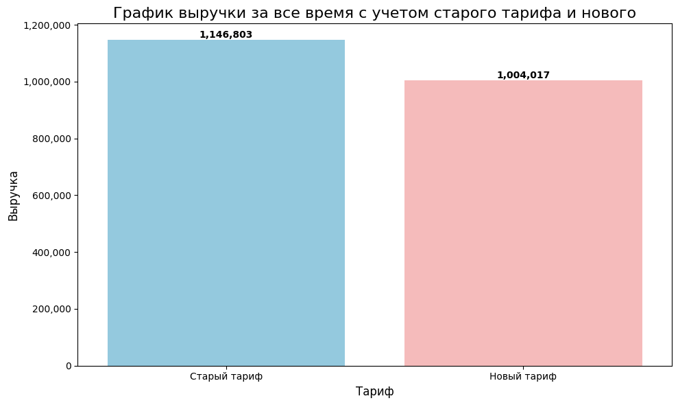

```python
# Подготовка данных
op = pd.DataFrame({
    'Тип дохода': ['Старый тариф', 'Новый тариф'],
    'Сумма': [group_plot['month_pay_total'].sum(), group_plot['new_month_pay_total'].sum()]
})

# Создаем фигуру
plt.figure(figsize=(10, 6))

# Создаем столбчатую диаграмму
ax = sns.barplot(x='Тип дохода', y='Сумма', data=op, palette=['skyblue', '#FFB1B1'])

# Добавляем значения над столбцами
for i, v in enumerate(op['Сумма']):
    ax.text(i, v, f'{v:,.0f}', ha='center', va='bottom', fontweight='bold')


# Настройка графика
plt.title('График выручки за все время с учетом старого тарифа и нового', fontsize=16)
plt.xlabel('Тариф', fontsize=12)
plt.ylabel('Выручка', fontsize=12)

# Форматирование оси Y для больших чисел
ax.yaxis.set_major_formatter(plt.FuncFormatter(lambda x, p: format(int(x), ',')))

# Отображение графика
plt.tight_layout()
plt.show()
```

Разница в выручке 12 процентов

```python
abs((group_plot['new_month_pay_total'].sum() - group_plot['month_pay_total'].sum()) / group_plot['month_pay_total'].sum() * 100)
```

```
12.450852517528311
```

**Строим график выручки по месяцам**

Меняем тип данных, так как иначе график не строится.

```python
group_plot['month'] = group_plot['month'].astype(str)
```

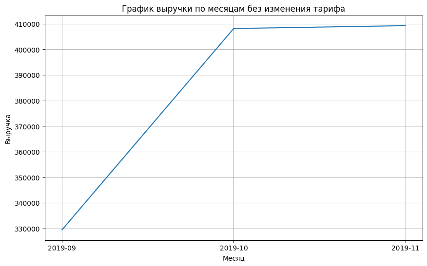

```python
plt.figure(figsize=(10, 6))
sns.lineplot(x='month', y='month_pay_total', data=group_plot)

plt.title('График выручки по месяцам без изменения тарифа')
plt.xlabel('Месяц')
plt.ylabel('Выручка')
plt.grid(True)
plt.show()
```

На графике видно как выручка растет на 23 процента и достигает пика на 10 месяце, потом выручка стабилизируется и идет ровно.

Подготавливаем данные, чтобы показать, сколько будет упущено выручки на клиентах, которым предложен новый тариф.

```python
not_same = merge_out.query('new_tariff != "same"')
```

```python
not_same.head()
```

|  | tariff_plan | month | user_id | out_call_min | month_pay | over_limit_cost | out_call_cost | add_pay | total_min_x | over_pay | over_a | over_b | total_min_y | price | oper_total | oper_price | month_pay_total | new_tariff | new_month_pay_total | percent_diff |
| --- | --- | --- | --- | --- | --- | --- | --- | --- | --- | --- | --- | --- | --- | --- | --- | --- | --- | --- | --- | --- |
| 0 | A | 2019-09 | 166407 | 2000 | 4000 | 0.1 | 0.3 | 50 | 608.0 | 0.0 | 0.0 | 108.0 | 0.0 | 0.0 | 6 | 300 | 4300.0 | B | 2916.20 | 32.2 |
| 1 | A | 2019-09 | 166407 | 2000 | 4000 | 0.1 | 0.3 | 50 | 0.0 | 0.0 | 0.0 | 0.0 | 384.0 | 115.2 | 6 | 300 | 4415.2 | B | 3092.00 | 30.0 |
| 2 | A | 2019-09 | 166541 | 2000 | 4000 | 0.1 | 0.3 | 50 | 913.0 | 0.0 | 0.0 | 413.0 | 784.0 | 235.2 | 4 | 200 | 4435.2 | B | 3053.95 | 31.1 |
| 3 | A | 2019-09 | 166713 | 2000 | 4000 | 0.1 | 0.3 | 50 | 41.0 | 0.0 | 0.0 | 0.0 | 0.0 | 0.0 | 2 | 100 | 4100.0 | B | 2300.00 | 43.9 |
| 4 | A | 2019-09 | 166879 | 2000 | 4000 | 0.1 | 0.3 | 50 | 262.0 | 0.0 | 0.0 | 0.0 | 0.0 | 0.0 | 3 | 150 | 4150.0 | B | 2450.00 | 41.0 |

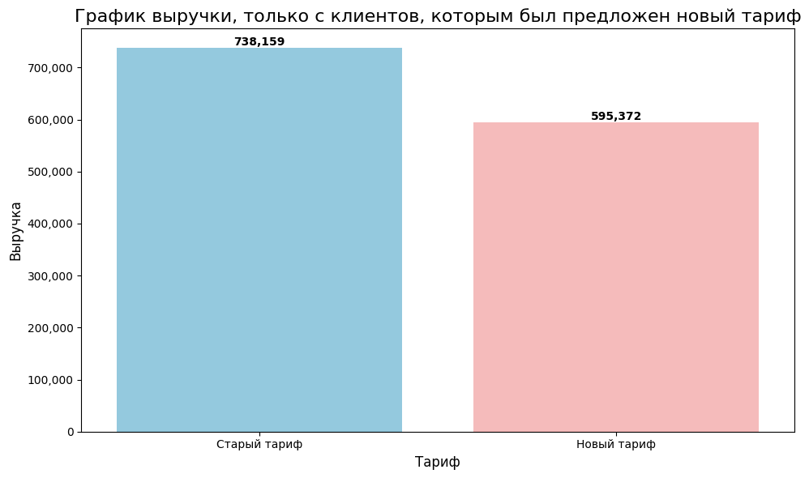

```python
# Подготовка данных
op_1 = pd.DataFrame({
    'Тип дохода': ['Старый тариф', 'Новый тариф'],
    'Сумма': [not_same['month_pay_total'].sum(), not_same['new_month_pay_total'].sum()]
})

# Создаем фигуру
plt.figure(figsize=(10, 6))

# Создаем столбчатую диаграмму
ax = sns.barplot(x='Тип дохода', y='Сумма', data=op_1, palette=['skyblue', '#FFB1B1'])

# Добавляем значения над столбцами
for i, v in enumerate(op_1['Сумма']):
    ax.text(i, v, f'{v:,.0f}', ha='center', va='bottom', fontweight='bold')


# Настройка графика
plt.title('График выручки, только с клиентов, которым был предложен новый тариф', fontsize=16)
plt.xlabel('Тариф', fontsize=12)
plt.ylabel('Выручка', fontsize=12)

# Форматирование оси Y для больших чисел
ax.yaxis.set_major_formatter(plt.FuncFormatter(lambda x, p: format(int(x), ',')))

# Отображение графика
plt.tight_layout()
plt.show()
```

```python
abs((not_same['new_month_pay_total'].sum() - not_same['month_pay_total'].sum()) / not_same['month_pay_total'].sum() * 100)
```

```
19.343645208002012
```

Потери в выручки с клиентов, которые перешли на новый тариф составит 19 процентов.

При этом в среднем клиент, который перешел на новый тариф будет экономить 20 процентов.

```python
not_same['percent_diff'].mean()
```

```
20.115882352941174
```

## Проверка статистических гипотез

Подготавливаем данные

```python
merge_out['total_min_x_y'] = merge_out['total_min_x'] +  merge_out['total_min_y']
```

```python
tariff_a = plot_revenue[plot_revenue['tariff_plan'] == 'A']['month_pay_total']
tariff_b = plot_revenue[plot_revenue['tariff_plan'] == 'B']['month_pay_total']
```

Смотрим как распределены величины

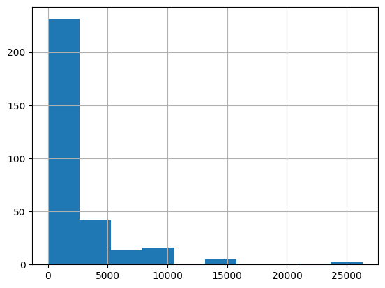

```python
merge_out['total_min_x_y'].hist()
```

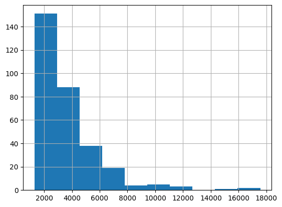

```python
plot_revenue['month_pay_total'].hist()
```

Видно что данные распределены ненормально, поэтому вибираем тест Манна-Уитни.

Различаются ли средние чеки клиентов на тарифах A и B?

H0 = среднии чеки клиентов на тарифах A и B не различаются; H1 = средние чеки клиентов на тарифах A и B различаются.

Проведем тест Манна-Уитни.

```python
statistic, p_value = stats.mannwhitneyu(tariff_a, tariff_b)


print(f"Статистика: {statistic}")
print(f"P-значение: {p_value}")


alpha = 0.05


if p_value < alpha:
    print("Отвергаем нулевую гипотезу.")
    print("Есть статистически значимое различие между средними чеками клиентов на тарифах A и B.")
else:
    print("Не отвергаем нулевую гипотезу.")
    print("Нет статистически значимого различия между средними чеками клиентов на тарифах A и B.")
```

```
Статистика: 4136.5
P-значение: 3.851750193320598e-09
Отвергаем нулевую гипотезу.
Есть статистически значимое различие между средними чеками клиентов на тарифах A и B.
```

Проведем тест Манна-Уитни.

Различается ли средняя продолжительность общего времени исходящего звонка у клиентов в зависимости от тарифов A и B?

H0 = средняя продолжительность общего времени исходящего звонка у клиентов тарифов A и B не различаются;

H1 = средняя продолжительность общего времени исходящего звонка у клиентов тарифов A и B различаются.

```python
tarif_a = merge_out[merge_out['tariff_plan'] == 'A']['total_min_x_y']
tarif_b = merge_out[merge_out['tariff_plan'] == 'B']['total_min_x_y']


statistic, p_value = stats.mannwhitneyu(tarif_a, tarif_b)


print(f"Статистика: {statistic}")
print(f"P-значение: {p_value}")


alpha = 0.05


if p_value < alpha:
    print("Отвергаем нулевую гипотезу.")
    print("Есть статистически значимое различие между средней продолжительностью исходящего звонка между клиентами на тарифах A и B.")
else:
    print("Не отвергаем нулевую гипотезу.")
    print("Нет статистически значимого различия между средней продолжительностью исходящего звонка между клиентами на тарифах A и B.")
```

```
Статистика: 2447.0
P-значение: 0.7489788249457184
Не отвергаем нулевую гипотезу.
Нет статистически значимого различия между средней продолжительностью исходящего звонка между клиентами на тарифах A и B.
```

## Вывод

В данных были обнаружены пропуски. В столбце internal пропущено 117 значений, что составляет 0,22% от общего числа. В столбце operator_id пропущено 8172 значения, или 15%. Также было выявлено 4900 дублированных строк, что составляет 9% от общего количества.

Было установлено, что большинство пользователей совершают от одного до пяти звонков в день. Продолжительность звонков, включая время гудков, варьируется от 46 минут до 901 минуты.

Стоит отметить, что 50% звонков остаются без ответа. В 9 и 10 месяце 7% клиентов, или 21 клиент, не совершили ни одного звонка. В 8 месяце 72% клиентов говорили 0 минут, а в 9 — 43%.

На основе этих данных было решено отобрать пользователей для дальнейшего анализа. В результате в таблицу вошли 109 клиента.

В результате была создана таблица the_end, в которой отражены клиенты, использующие неоптимальный тариф всего их 71. Из таблицы видно, что чаще всего клиентам с тарифом «B» предлагалось перейти на новый тариф.

Также было проведено два статистических теста Манна-Уитни. Один из тестов выявил, что средняя продолжительность общего времени исходящего звонка у клиентов с тарифов A и B не различается. Поэтому потенциально клиенты с тарифом 'A' используют его неоптимально.

В завершение хотелось бы отметить, что клиенты, переходящие на новый тариф, в среднем могут сэкономить до 20%.

Также были построены графики, отражающие разницу в выручке в зависимости от того, остался клиент на старом тарифе или перешел на новый. Эта информация отображена в презентации по этой ссылке https://disk.yandex.ru/i/qLLElvxDb9YPJQ

```python
the_end
```

|  | user_id | tariff_plan | new_tariff |
| --- | --- | --- | --- |
| 0 | 166879 | A | B |
| 1 | 167185 | A | B |
| 2 | 166901 | A | B |
| 3 | 166843 | A | B |
| 4 | 166725 | A | B |
| ... | ... | ... | ... |
| 66 | 167109 | C | A |
| 67 | 167150 | C | B |
| 68 | 167650 | C | A |
| 69 | 167031 | C | B |
| 70 | 167532 | C | B |

71 rows × 3 columns